# Modélisation ARMA-GARCH et estimation des Réponses Impulsionnelles de Volatilité (VIRF) sur le prix du TTF

Bregeon Pierre - Chalmot Edouard - Dassa Benjamin

Décembre 2024

# 1 Introduction

Le **Title Transfer Facility (TTF)** est une place de marché virtuelle pour le gaz naturel située aux Pays-Bas. Créé en 2003, le TTF est devenu l’un des principaux hubs gaziers en Europe et une référence mondiale pour la fixation des prix du gaz.

Le TTF permet aux acteurs du marché de négocier des contrats de gaz naturel pour une livraison physique ou à des fins de couverture financière via des produits dérivés. Grâce à sa liquidité élevée et à la diversité de ses participants, le TTF sert désormais de **point de référence pour le prix du gaz naturel en Europe**, influençant également les marchés mondiaux de l’énergie. En tant que hub le plus liquide d’Europe, il est utilisé comme **indice de référence** pour les contrats de gaz à long terme entre producteurs, fournisseurs et consommateurs en Europe.

Les prix du TTF ont été relativement stables entre 2017 et 2020, mais plusieurs chocs majeurs ont profondément perturbé les marchés du gaz depuis 2021 :

- **Pandémie de COVID-19 (2020-2021) :** Une reprise économique rapide a entraîné une hausse de la demande de gaz en Europe et dans le monde.
- **Guerre en Ukraine (2022) :** L’invasion de l’Ukraine par la Russie a provoqué une **crise énergétique majeure en Europe**, exacerbée par la réduction drastique des livraisons de gaz russe. En conséquence, les prix du TTF ont atteint des niveaux records, dépassant parfois 300 €/MWh, un phénomène sans précédent.

Ces chocs mettent en évidence l’importance de **comprendre les dynamiques sous-jacentes des prix du TTF**, ainsi que l’impact des événements géopolitiques sur les marchés de l’énergie.

L’objectif principal de ce projet est de **modéliser la volatilité des rendements du TTF** sur la période 2017-2024, avec un focus particulier sur les conséquences de la guerre en Ukraine. En analysant les Volatility Impulse Response Function de cette série temporelle, cette étude vise à déterminer l’**impact du choc géopolitique** de 2022 sur le comportement de la volatilité des prix du gaz naturel.

## 1.1 Contexte et problématique

Nous cherchons à répondre à la question suivante:

**Comment l’invasion de l’Ukraine a-t-elle impacté la volatilité des rendements du prix du gaz naturel sur le marché des contrats à terme ?**

Quelques travaux académiques ont déjà mis en lumière l’impacts de ce conflit :

Dans notre étude nous modélisons les rendements du TTF avec un modèle ARMA-GARCH. On fait un premier modèle avant l’invasion de l’Ukraine puis un second après. Après diagnostics des modèles nous étudions le comportement de la volatilité conditionnelle avant et après l’invasion de l’Ukraine en réalisant des Volatility Impulse Response Function.

## 1.2 Le choix du marché TTF

Notre étude se concentre sur les prix du **Dutch TTF Natural Gas Futures**, car le TTF est un hub de référence pour le gaz naturel en Europe. Les prix des contrats à terme sur ce marché influencent les coûts de l’énergie dans plusieurs pays européens. Ces contrats à terme permettent aux acteurs de l’énergie de sécuriser leurs prix pour des livraisons futures, en spécifiant des quantités standard de **1 MW/jour** sur des périodes mensuelles, trimestrielles ou annuelles.

## 1.3 Données utilisées

Les données utilisées dans cette étude proviennent du site **Investing.com**. Ce sont des données journalières (jours ouvrés, ouverture des marchés) qui couvrent la période du **23 octobre 2017 au 6 novembre 2024**, et incluent :

- Les prix de clôture journaliers,
- Les prix d’ouverture,
- Les prix maximums et minimums,
- Le volume de transactions,
- Les variations en pourcentage.

Pour étudier la dynamique des prix nous utiliserons le prix de clôture journalier.

Nous avons commencé par charger les données depuis GitHub et trier les dates par ordre croissant pour calculer les rendements par la suite.

# 2 Analyse de la série du ttf

## 2.1 Série entière

### 2.1.1 Evolution des prix :

On commence par analyser l’évolution du prix de la série :

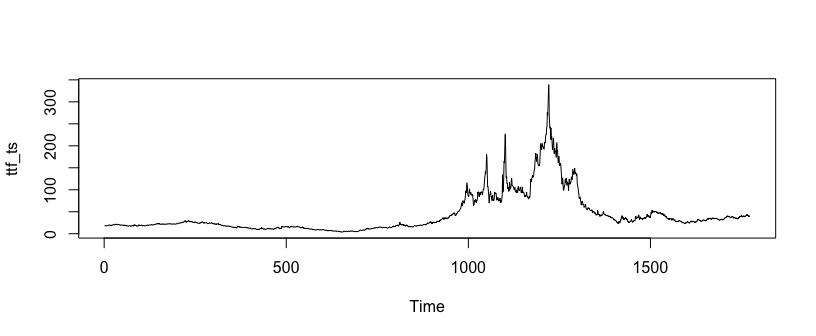

1. *Période stable (23-10-2017 à juin 2021)*

   Pendant cette période, les prix du TTF semblent relativement stables, oscillant autour de faibles niveaux. Cela pourrait refléter une offre et une demande équilibrées sur le marché du gaz naturel européen, sans perturbations majeures.
2. *Premier choc (Juin 2021)*

   L’augmentation soudaine des prix coïncide avec une combinaison de facteurs : La reprise économique mondiale post-COVID-19, entraînant une augmentation de la demande énergétique. Des problèmes d’approvisionnement en gaz en Europe, notamment la baisse des exportations de la Russie et des stocks bas à la sortie de l’hiver 2020-2021. Ces conditions ont entraîné une volatilité accrue, observable par les fluctuations marquées de cette période.
3. *Choc majeur (Février 2022) :*

   Le début de la guerre en Ukraine marque une rupture brutale dans la série. Les prix atteignent des niveaux records en raison de : l’incertitude géopolitique autour des approvisionnements en gaz russe, principal fournisseur de l’Europe. Les sanctions économiques et les interruptions volontaires ou involontaires des flux de gaz. L’anticipation d’un déficit d’offre sur le marché européen. La volatilité est particulièrement élevée, reflétant les tensions extrêmes et l’incertitude sur le marché.

Après le pic, les prix montrent une tendance à la baisse, bien qu’ils restent supérieurs aux niveaux d’avant 2021.

En analysant cette série temporelle, on voit que cette courbe n’est pas stationnaire car il ne semble pas y avoir de retour à la moyenne évident. Cela sera vérifié plus tard.

### 2.1.2 Évolution des prix par années

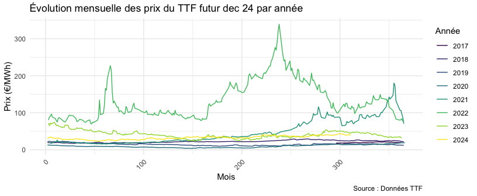

## 2.2 Calcul des rendements

On transforme notre série en rendements logarithmique :
$$R_t = \ln\left( \frac{P_t}{P_{t-1}} \right)$$

Dans les séries financières, le calcul des rendements permet souvent de transformer la série de base en série stationnaire. En effet, comme dit précédemment la série du ttf ne présente pas des caractéristiques de série stationnaire, et présente souvent des tendances. La transformation en rendement permet d’éliminer ces tendances. De plus, il mettent en évidence la volatilité des prix. Les modèles comme le GARCH, qui sera utilisé après, utilise les rendements comme variable centrale comme le montre le chapitre 12 du livre de Cryer et Chan.

On calcul les rendements sur la série entière :

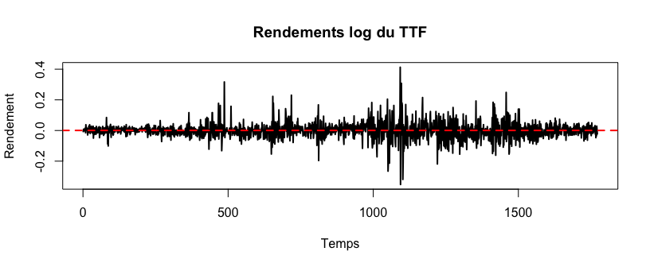

La série des rendements présente des caractéristiques de série stationnaire avec un retour à la moyenne plutôt clair. Cependant bien que la moyenne soit stable, la série présente des épisodes de volatilité très élevée ce qui pourrait être lié à des chocs spécifiques.

### 2.2.1 Statistiques descriptives :

```
##       Min.    1st Qu.     Median       Mean    3rd Qu.       Max.
## -0.3524137 -0.0248177  0.0000000  0.0004419  0.0233074  0.4127881
```

Les rendements oscillent autour de zéro, avec des variations positives et négatives globalement équilibrées. Les valeurs extrêmes, qu’il s’agisse des baisses les plus fortes (-35,24 %) ou des hausses les plus marquées (+41,28 %), reflètent les chocs importants caractéristiques des marchés financiers. La majorité des rendements se situent cependant dans une plage modérée, entre -2,48 % (q1) et +2,33 % (q3), bien que des événements exceptionnels puissent parfois provoquer des fluctuations bien plus importantes.

Plusieurs options s’offrent à nous pour étudier la série temporelle des prix du ttf. Notre volonté est d’étudier l’impact du choc de la guerre en Ukraine en février 2022 sur le prix du gaz. Cependant nous avons vu qu’un choc était présent avant en 2021 ce qui pourrait nécessiter de modéliser ce choc aussi.

Pour choisir nos fenêtres d’analyse nous procédons ainsi :

1. Nous découpons la série en 3 périodes : Avant la premier choc (Début de la série - 2021-05-28) ; Avant le deuxième choc (Début de la série - 2022-02-22) et après le début de la guerre (2022-02-22 - Fin de la série)
2. Nous étudierons la stationnarité des séries avant le premier choc et avant le deuxième choc pour choisir la manière de modéliser la série. Si les rendements de la série avant le deuxième choc sont stationnaires, nous choisirons cette fenêtre d’analyse et de modélisation pour nous concentrer sur l’impact de l’invasion de Ukraine.
3. Nous modéliserons la fenêtre choisie avec des modèles spécifiques aux séries financières (GARCH / ARMA-GARCH)

### 2.2.2 Analyse de la stationnarité des rendements :

#### 2.2.2.1 Première fenêtre d’analyse-Avant la premier choc (2021-05-28) :

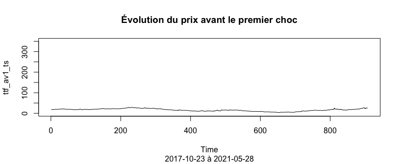

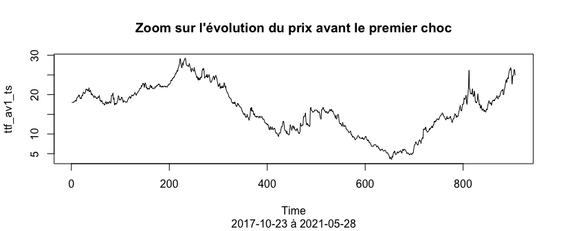

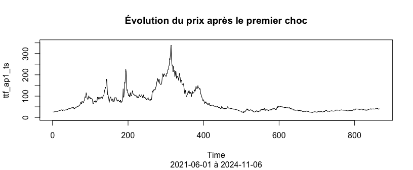

On voit sur le deuxième graphique que la première fenêtre qui semblait plutôt stable dans le graphique général 1 varie en entre 5 et 30 ce qui est quand même considérable pour les prix du gaz. En effet, les chocs des périodes suivantes sont importants, emmenant le prix à près de 350 ce qui est largement supérieur.

Cette première fenêtre n’a pas les caractéristiques d’une série stationnaire. Nous allons alors calculer les rendements et regarder la stationnarité de la série.

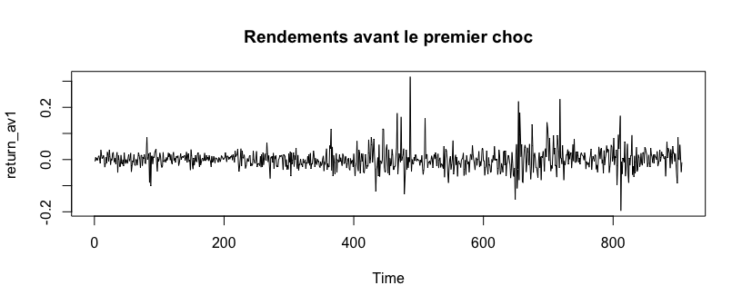

Il semble exister un retour à la moyenne. Pour vérifier si les rendements du ttf sur cette première fenêtre sont stationnaires on utilise le test de Dickey-Fuller augmenté (ADF). L’hypothèse nulle de ce test étant que la série possède une racine unitaire et est donc non stationnaire.

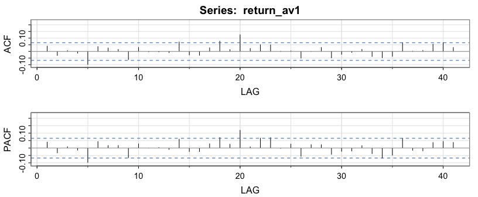

```
## Augmented Dickey-Fuller Test
## alternative: stationary
##
## Type 1: no drift no trend
##      lag   ADF p.value
## [1,]   0 -28.9    0.01
## [2,]   1 -21.5    0.01
## [3,]   2 -17.3    0.01
## [4,]   3 -15.2    0.01
## [5,]   4 -14.9    0.01
## [6,]   5 -12.8    0.01
## [7,]   6 -11.5    0.01
## Type 2: with drift no trend
##      lag   ADF p.value
## [1,]   0 -28.9    0.01
## [2,]   1 -21.5    0.01
## [3,]   2 -17.3    0.01
## [4,]   3 -15.2    0.01
## [5,]   4 -14.9    0.01
## [6,]   5 -12.8    0.01
## [7,]   6 -11.5    0.01
## Type 3: with drift and trend
##      lag   ADF p.value
## [1,]   0 -28.9    0.01
## [2,]   1 -21.5    0.01
## [3,]   2 -17.3    0.01
## [4,]   3 -15.2    0.01
## [5,]   4 -15.0    0.01
## [6,]   5 -12.8    0.01
## [7,]   6 -11.6    0.01
## ----
## Note: in fact, p.value = 0.01 means p.value <= 0.01
```

Cependant pour vérifier ceci, on analyse la p-valeur du test ADF. Cette p-valeur est de 0.01, inférieure à 0.05 donc on rejette l’hypothèse nulle de non-stationnarité et les rendements sur cette première fenêtre sont stationnaires.

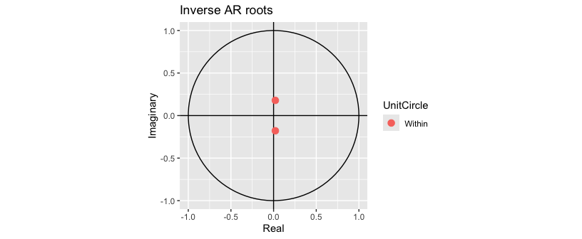

On n’a aucune racine égale à 1 (aucun point rouge sur le cercle), ainsi ce processus est I(0). On conclut que la série est stationnaire. On est à présent en mesure de modéliser le comportement de cette série.

#### 2.2.2.2 Deuxième fenêtre d’analyse, avant le deuxième choc (2022-02-22) :

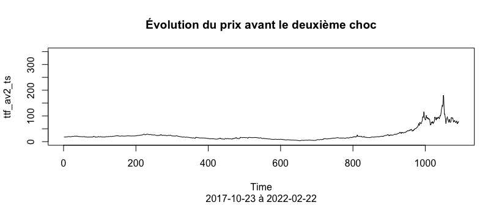

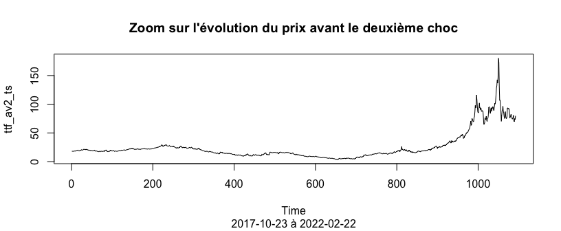

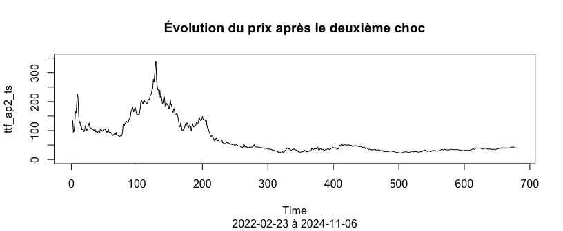

Cette deuxième fenêtre ne semble pas avoir les caractéristiques d’une série stationnaire. Nous allons alors calculer les rendements et regarder la stationnarité de la série.

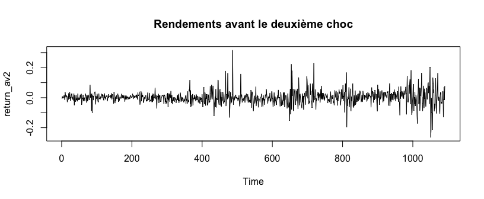

Il semble y exister un retour à la moyenne, la série semble stationnaire, nous calculons les ACF/PACF et faisons un test de Dickey Fuller et de KPSS

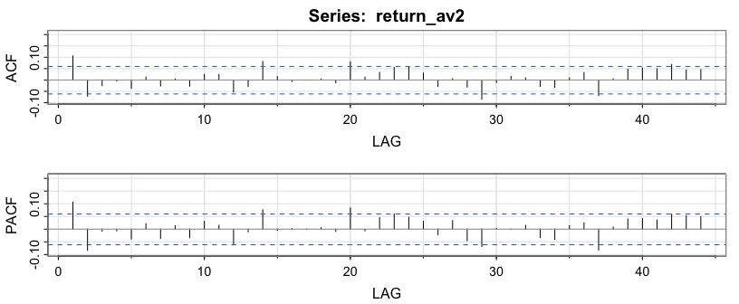

```
## Augmented Dickey-Fuller Test
## alternative: stationary
##
## Type 1: no drift no trend
##      lag   ADF p.value
## [1,]   0 -29.6    0.01
## [2,]   1 -23.9    0.01
## [3,]   2 -19.4    0.01
## [4,]   3 -16.8    0.01
## [5,]   4 -15.6    0.01
## [6,]   5 -13.7    0.01
## [7,]   6 -13.1    0.01
## Type 2: with drift no trend
##      lag   ADF p.value
## [1,]   0 -29.6    0.01
## [2,]   1 -23.9    0.01
## [3,]   2 -19.5    0.01
## [4,]   3 -16.9    0.01
## [5,]   4 -15.6    0.01
## [6,]   5 -13.8    0.01
## [7,]   6 -13.2    0.01
## Type 3: with drift and trend
##      lag   ADF p.value
## [1,]   0 -29.6    0.01
## [2,]   1 -24.0    0.01
## [3,]   2 -19.5    0.01
## [4,]   3 -16.9    0.01
## [5,]   4 -15.7    0.01
## [6,]   5 -13.9    0.01
## [7,]   6 -13.3    0.01
## ----
## Note: in fact, p.value = 0.01 means p.value <= 0.01
```

```
## $type1
##      lag       ADF p.value
## [1,]   0 -29.58697    0.01
## [2,]   1 -23.90630    0.01
## [3,]   2 -19.43976    0.01
## [4,]   3 -16.82359    0.01
## [5,]   4 -15.55673    0.01
## [6,]   5 -13.73086    0.01
## [7,]   6 -13.12684    0.01
##
## $type2
##      lag       ADF p.value
## [1,]   0 -29.59861    0.01
## [2,]   1 -23.92585    0.01
## [3,]   2 -19.46452    0.01
## [4,]   3 -16.85243    0.01
## [5,]   4 -15.59127    0.01
## [6,]   5 -13.76737    0.01
## [7,]   6 -13.16741    0.01
##
## $type3
##      lag       ADF p.value
## [1,]   0 -29.64996    0.01
## [2,]   1 -23.99584    0.01
## [3,]   2 -19.54419    0.01
## [4,]   3 -16.94247    0.01
## [5,]   4 -15.69515    0.01
## [6,]   5 -13.87839    0.01
## [7,]   6 -13.29403    0.01
```

```
## KPSS Unit Root Test
## alternative: nonstationary
##
## Type 1: no drift no trend
##  lag  stat p.value
##    7 0.215     0.1
## -----
##  Type 2: with drift no trend
##  lag stat p.value
##    7 0.42  0.0684
## -----
##  Type 1: with drift and trend
##  lag  stat p.value
##    7 0.114     0.1
## -----------
## Note: p.value = 0.01 means p.value <= 0.01
##     : p.value = 0.10 means p.value >= 0.10
```

Les ACF / PACF montrent que la série semble avoir des caractéristiques de série stationnaire. On voit qu’un premier pic légèrement significatifs au lag 1/2 ce qui pourrait venir des erreurs potentielles de test à 5%.

Les tests de Dickey Fuller et du KPSS donnent les mêmes conclusions : La série est stationnaire avec ou sans drift.

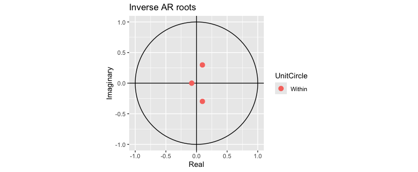

Le test de Tiao-Tsay confirme cela. La série est I(0), il n’y a pas de racine unitaire.

Finalement, les séries sur les deux premières fenêtres d’analyse sont stationnaires. Pour évaluer l’impact de la guerre en Ukraine sur les prix du TTF on va choisir la deuxième fenêtre du début de la série au 22 février 2022.

# 3 Modélisation :

Les séries financières présentent généralement deux composantes clés qui permettent de modéliser leurs dynamiques temporelles :

- **La partie ARMA (Autoregressive Moving Average)** utilisée pour capturer les dynamiques de la **moyenne conditionnelle**.
- **La partie GARCH (Generalized Autoregressive Conditional Heteroskedasticity)** qui modélise la v**ariance conditionnelle**, en capturant les variations temporelles de la volatilité.

Ces deux composantes, combinées dans un modèle ARMA-GARCH, permettent de capturer à la fois la dépendance des rendements dans le temps (moyenne) et les dynamiques de la volatilité (variance).

Avant de modéliser un ARMA GARCH, on veut être certains que le modèle ARMA-GARCH est pertinent avec nos données. On veut donc être certains que notre série présente de la variance conditionnelle. Pour cela, on va étudier les résidus d’un modèle ARMA sur nos données.

## 3.1 Modélisation de la moyenne conditionnelle - ARMA :

### 3.1.1 Identification de l’ARMA(p,q)

On commence par réaliser les EACF

```
## AR/MA
##   0 1 2 3 4 5 6 7 8 9 10 11 12 13
## 0 x x o o o o o o o o o  o  o  x
## 1 x x o o o o o o o o o  o  o  x
## 2 x x o o o o o o o o o  o  o  x
## 3 x o x o o o o o o o o  o  o  x
## 4 x x x o o o o o o o o  o  o  x
## 5 x x x o x o o o o o o  o  o  x
## 6 x x o x x o o o o o o  o  o  o
## 7 x x o o x o o o o o o  o  o  o
```

L’EACF montre qu’un ARMA(0,2) pourrait convenir.

#### 3.1.1.1 ARMA(0,2)

```
##
## Call:
## arima(x = return_av2, order = c(0, 0, 2))
##
## Coefficients:
##          ma1      ma2  intercept
##       0.1125  -0.0653     0.0014
## s.e.  0.0304   0.0300     0.0014
##
## sigma^2 estimated as 0.001971:  log likelihood = 1849.86,  aic = -3693.72
##
## Training set error measures:
```

```
##               ME RMSE MAE MPE MAPE
## Training set NaN  NaN NaN NaN  NaN
```

Les coefficients sont significatifs. En effet on calcule Estimateur / Standard Error et on veut que la valeur soit supérieure, en valeur absolue, à 1.96.

- Pour ma1 : $|t_{ma1}|$ = 3.7 >1.96, le coefficient est significatif à 5%
- Pour ma2 : $|t_{ma2}|$ = 2.2 >1.96, le coefficient est significatif à 5%
- Pour l’interecept : $|t_{intercept}|$ = 1 < 1.96, le coefficient n’est pas significatif à 5%.

Nous allons tester avec p+1 et q+1 pour voir si le modèle spécifié est bien le meilleur.

#### 3.1.1.2 Test avec p+1 : ARMA(1,2)

```
##
## Call:
## arima(x = return_av2, order = c(1, 0, 2))
##
## Coefficients:
##          ar1      ma1      ma2  intercept
##       0.4761  -0.3616  -0.1238     0.0014
## s.e.  0.3761   0.3740   0.0435     0.0013
##
## sigma^2 estimated as 0.001969:  log likelihood = 1850.48,  aic = -3692.96
##
## Training set error measures:
```

```
##               ME RMSE MAE MPE MAPE
## Training set NaN  NaN NaN NaN  NaN
```

- Pour ma1 : $|t_{ma1}|$ = 0.97 < 1.96, le coefficient n’est pas significatif à 5%.
- Pour ma2 : $|t_{ma2}|$ = 2.85 > 1.96, le coefficient est significatif à 5%.
- Pour ar1 : $|t_{ar1}|$ = 1.26 < 1.96, le coefficient n’est pas significatif à 5%.
- Pour l’interecept : $|t_{intercept}|$ = 1.07 < 1.96, le coefficient n’est pas significatif à 5%.

Ainsi rajouter AR(1) fait perdre de la significativité au modèle.

#### 3.1.1.3 Test avec q+1 : ARMA(0,3)

```
##
## Call:
## arima(x = return_av2, order = c(0, 0, 3))
##
## Coefficients:
##          ma1      ma2      ma3  intercept
##       0.1149  -0.0718  -0.0310     0.0014
## s.e.  0.0304   0.0305   0.0299     0.0014
##
## sigma^2 estimated as 0.001969:  log likelihood = 1850.4,  aic = -3692.8
##
## Training set error measures:
```

```
##               ME RMSE MAE MPE MAPE
## Training set NaN  NaN NaN NaN  NaN
```

- Pour ma1 : $|t_{ma1}|$ = 3.78 > 1.96, le coefficient est significatif à 5%.
- Pour ma2 : $|t_{ma2}|$ = 2.35 > 1.96, le coefficient est significatif à 5%.
- Pour ma3 : $|t_{ma3}|$ = 1.03 < 1.96, le coefficient n’est pas significatif à 5%.
- Pour l’interecept : $|t_{intercept}|$ = 1 < 1.96, le coefficient n’est pas significatif à 5%.

Le coefficient ma3 n’est pas significatif, ainsi nous restons sur le modèle de base ARMA(0,2)

### 3.1.2 Diagnostics du modèle :

#### 3.1.2.1 Analyse des résidus

##### 3.1.2.1.1 Test de Ljung-Box

Afin d’évaluer si les résidus du modèle arma sont indépendants, non autocorrélés, on réalise un test de Ljung-Box sur les résidus.

```
##
##  Box-Ljung test
##
## data:  residuals(arma02)
## X-squared = 6.8904, df = 10, p-value = 0.7357
```

Les résultats du test de Box-Ljung montrent une p-value de 0.7357, ce qui est bien supérieur au seuil de 5 %. Cela indique que nous ne pouvons pas rejeter l’hypothèse nulle selon laquelle les résidus du modèle ARMA(0,2) sont indépendants et ne présentent pas d’autocorrélation significative. Par conséquent, les résidus sont indépendants et ne présentent pas d’autocorrélation.

##### 3.1.2.1.2 ACF/PACF

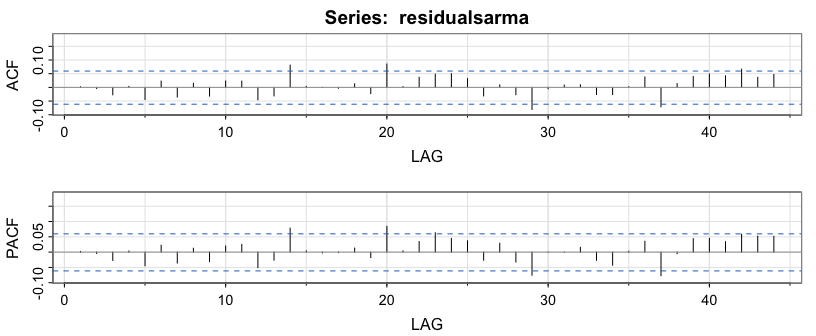

Les ACF/PACF des résidus confirment cela. Il n’y a pas d’autocorrélations dans les résidus. Donc la moyenne conditionnelle est bien modélisée par l’ARMA. On s’intéresse maintenant à la variance conditionnelle.

#### 3.1.2.2 Détection de potentiel hétéroscédasticité

Pour analyser une potentielle présence d’hétéroscédasticité, on analyse l’autocorrélation dans les résidus au carré. En effet dans une série avec hétéroscédasticité conditionnelle, la variance des résidus dépend des valeurs passées. Cela se traduit par une structure temporelle dans les résidus au carré ($\epsilon^2$).

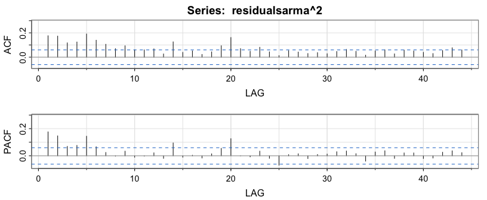

Plusieurs lags (en particulier les premiers) présentent des autocorrélations significatives. Cela suggère une **dépendance temporelle dans les variances** des résidus, ce qui est un signe clair d’hétéroscédasticité conditionnelle.

On confirme cette observation avec un test de Ljung-Box sur les résidus au carré.

```
##
##  Box-Ljung test
##
## data:  residualsarma^2
## X-squared = 178.61, df = 8, p-value < 2.2e-16
```

La p-valeur strictement inférieure à 5% montre bien que les résidus au carré présentent de l’autocorrélation. Les résidus présentent une **hétéroscédasticité**. Cela suggère que la variance des résidus n’est pas constante dans le temps. Ce résultat est cohérent avec le type de série que nous analysons qui sont des séries financières, où des périodes de forte volatilité alternent avec des périodes calmes.

#### 3.1.2.3 Test ARCH :

Pour vérifier si la variance des résidus dépend des valeurs passées et donc si la série des rendements présente de la volatilité conditionnelle on réalise un test ARCH (Autoregressive Conditional Heteroskedasticity). Les hypothèses du test ARCH sont les suivantes :

- Hypothèse nulle : Il n’y a pas d’effet ARCH. La variance des résidus est constante (homoscédasticité)
- Hypothèse alternative : Il existe un effet ARCH. La variance des résidus dépend des valeurs passées.

Pour réaliser ce test dans RStudio on utilise la fonction ArchTest du package FinTS. Ce package a été développé par Spencer Graves et est utilisé pour l’analyse de séries temporelles financières.

```
##
##  ARCH LM-test; Null hypothesis: no ARCH effects
##
## data:  residualsarma
## Chi-squared = 61.558, df = 3, p-value = 2.731e-13
```

La faible p-valeur du test ARCH signifie que la variance conditionnelle des résidus dépend des valeurs passées. Autrement dit, les résidus ne sont pas homoscédastiques, mais leur variance évolue dans le temps. Le modèle ARMA ne capture pas toutes les caractéristiques des rendements, en particulier il ignore la dynamique de la volatilité.

Pour capturer cette dynamique de volatilité conditionnelle on va utiliser un modèle GARCH.

## 3.2 Construction de la partie GARCH :

### 3.2.1 Le modèle général

Le modèle GARCH (Generalized Autoregressive Conditional Heteroskedasticity) est utilisé pour modéliser les séries temporelles financières, notamment lorsqu’elles présentent une volatilité hétéroscédastique. Ce type de modèle, introduit par Bollerslev (1986), étend le cadre du modèle ARCH (Engle, 1982).

Le GARCH repose sur l’idée que la variance conditionnelle des résidus n’est pas constante au cours du temps, mais qu’elle évolue en fonction d’une dynamique déterminée par les observations passées. Cette approche est particulièrement pertinente pour les séries financières où la volatilité montre des périodes de calme et d’agitation (cluster de volatilité). Formulé simplement, le modèle GARCH s’écrit comme suit :

$$y_t = \mu + \epsilon_t, \quad \epsilon_t
\sim N(0, \sigma_t^2),$$

où

- $y_t$ est la valeur de la série au temps $t$,
- $\mu$ est la moyenne conditionnelle,
- $\epsilon_t$ est le résidu

L’équation de la variance conditionnelle est :

$$\sigma_t^2 = \omega + \sum_{i=1}^p
\alpha_i \epsilon_{t-i}^2 + \sum_{j=1}^q \beta_j
\sigma_{t-j}^2,$$

où :

- $\sigma_t^2$ est la variance conditionnelle au temps t,
- $\omega > 0$ est un paramètre constant,
- $\alpha_i \geq 0$ capture l’impact des chocs passés ($\epsilon_{t-i}^2$) sur la volatilité actuelle,
- $\beta_j \geq 0$ représente l’effet de la persistance de la volatilité passée ($\sigma_{t-j}^2$).

### 3.2.2 Distribution des observations

Pour la construction de la partie GARCH d’un modèle ARMA-GARCH il est important de s’intéresser à la distribution des observations. Pour vérifier si les observations des rendements suivent une loi normale, et dans le cas inverse comment est caractérisée cette distribution nous réalisons le test de Jarque Bera et nous observons l’excès de kurtosis et la skewness. Le test de Jarque-Bera a comme hypothèse nulle que la série observé suit une distribution normale. La skewness mesure le degré d’asymétrie d’une distribution autour de sa moyenne et la kurtosis décrit les extrêmes de la distribution et la forme de ses queues. Dans le cas d’une loi normale ces paramètres valent respectivement 0 et 3.

```
##
##  Jarque-Bera Normality Test
##
## data:  as.numeric(return_av2)
## JB = 2453.1, p-value < 2.2e-16
## alternative hypothesis: greater
```

```
## Excess Kurtosis = 4.280809
```

```
## Skewness = 0.4879769
```

La p-valeur du test de Jarque-Bera est extrêmement faible (<5%), ce qui conduit au rejet de l’hypothèse nulle. Cela signifie que la distribution des rendements ne suit pas une loi normale. Ce constat est renforcé par l’excès de kurtosis, nettement supérieur à 0, et une skewness positive. L’excès de kurtosis indique que la distribution possède des queues épaisses, ce qui suggère une fréquence plus élevée de valeurs extrêmes par rapport à une loi normale. La skewness de 0.49 révèle une asymétrie à droite, avec une queue plus longue du côté des rendements positifs. Ainsi, les rendements positifs extrêmes sont plus fréquents que les rendements négatifs extrêmes.

Afin d’examiner la distribution des rendements, nous les représentons graphiquement et comparons leur densité empirique avec une distribution normale ajustée. Cette comparaison permet de mettre en évidence les éventuels écarts, tels que des asymétries ou des queues épaisses

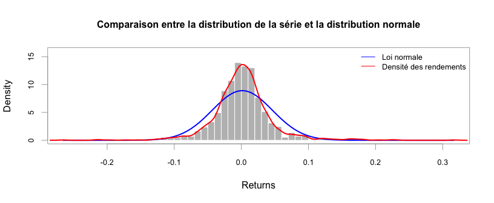

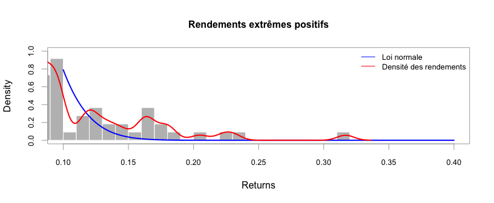

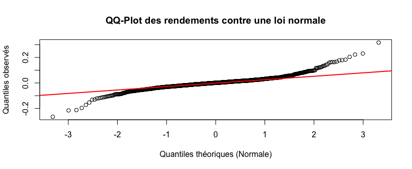

Ce graphique montre que la distribution des rendements du ttf diffère de la distribution normale. Elle est caractérisée par :

- Une **kurtosis élevée** (point central plus fin et queues épaisses).
- Une **skewness positive** (légère asymétrie à droite).

  Ainsi on peut utiliser d’autres distributions notamment une skewed Student-t ou une Student généralisée pour capturer ces écarts à la normalité.

Le diagramme Quantile-Quantile confirme ces résultats, au centre de la distribution les rendements ressemblent à une loi normale mais au niveau de la q**ueue de gauche** les points dévient fortement sous la ligne rouge et au niveau de la **Queue de droite l**es points dévient également au-dessus de la ligne rouge.

Ainsi la distribution des rendements **n’est pas normale**.

Ces observations des rendements correspondent plutôt à une distribution de Skew-t qui capture mieux l’asymétrie et les queues épaisses. Comme il y a présence d’hétéroscédasticité, nous modélisons le GARCH avec cette distribution puis nous vérifierons, dans les diagnostics, que les résidus du modèle suivent aussi une Skew-t.

### 3.2.3 Identification de la partie GARCH(p,q)

Nous avons précédemment détecté de l’hétéroscédasticité. On va tester différentes structures de GARCH et d’ARMA. D’après la littérature et les eacf des rendements au carré présentés ci-dessous, on commence cette modélisation avec un ordre 1,1 pour la partie GARCH du modèle. Pour la partie de la moyenne conditionnelle, on va se baser sur le modèle ARMA précédent (p=0, q=2).

La modélisation ARMA-GARCH est réalisée dans Rstudio avec la version 1.5-3 du package rugarch développé par Gallianos (2024). Pour cette étude, nous avons choisi d’utiliser le modèle Simple GARCH (“sGARCH” dans rugarch), car il s’agit du modèle de base introduit par Bollerslev, sans extensions spécifiques. Ce modèle est le plus élémentaire parmi les variantes du GARCH et constitue une première approche solide pour modéliser la volatilité conditionnelle des séries temporelles financières.

```
## AR/MA
##   0 1 2 3 4 5 6 7 8 9 10 11 12 13
## 0 x x x x x x x x x o x  x  o  x
## 1 x o o o x o o o o o o  o  o  x
## 2 x x o o x o o o o o o  o  o  x
## 3 x o x o x o o o o o o  o  o  x
## 4 x x x x x o o o o o o  o  o  x
## 5 x o x x x o o o o o o  o  o  o
## 6 x o o x x o o o o o o  o  o  o
## 7 x x x o o x x o o o o  o  o  o
```

Dans la sortie des coefficients du GARCH, on a des estimateurs avec les erreurs standards classiques et d’autres avec les erreurs standards robustes. On utilise les coefficients optimaux avec les erreurs standards classiques. Cependant, si on se rend compte de problèmes dans la modélisation, on utilisera plus tard les erreurs standards robustes. Avec le package rugarch, beaucoup d’estimateurs et de tests sont calculés, pour cette partie on utilisera le tableau ci-dessous qui présente les estimateurs de l’ARMA-GARCH avec leurs p-valeurs.

Coefficients des estimateurs du modèle ARMA(0,2)-GARCH(1,1)

| Parameter | Estimate | P.Value |
| --- | --- | --- |
| mu | 0.0010051 | 0.2870725 |
| ma1 | 0.0723823 | 0.0201669 |
| ma2 | -0.0391271 | 0.1908394 |
| omega | 0.0000315 | 0.0250423 |
| alpha1 | 0.1599803 | 0.0000006 |
| beta1 | 0.8390194 | 0.0000000 |
| skew | 1.0284882 | 0.0000000 |
| shape | 5.2945046 | 0.0000000 |

Pour l’ARMA(0,2)-GARCH (1,1). On observe que le coefficient ma2 n’est pas significatif. Nous devons alors ajuster cette partie en baissant l’ordre de l’ARMA(0,2) en ARMA(0,1). On obtient les résultats ci-dessous.

#### 3.2.3.1 Ajustement de la partie ARMA de l’ARMA-GARCH

##### 3.2.3.1.1 ARMA(0,1)-GARCH(1,1)

Coefficients des estimateurs du modèle ARMA(0,1)-GARCH(1,1)

| Parameter | Estimate | P.Value |
| --- | --- | --- |
| mu | 0.0010201 | 0.2942581 |
| ma1 | 0.0746809 | 0.0213977 |
| omega | 0.0000314 | 0.0245905 |
| alpha1 | 0.1597810 | 0.0000007 |
| beta1 | 0.8392189 | 0.0000000 |
| skew | 1.0294643 | 0.0000000 |
| shape | 5.3006518 | 0.0000000 |

Les coefficients ma1, omega, alpha1 et beta1 sont significatifs. Nous allons maintenant faire le même travail que dans la modélisation d’un ARMA en augmentant les coefficients de p+1 et q+1. Pour la partie ARMA, on a déjà vu que la modélisation de la moyenne conditionnelle avec un ARMA(0,2) n’était pas significative, nous devons alors tester avec un ARMA(1,1)

##### 3.2.3.1.2 ARMA(1,1)-GARCH(1,1)

Le tableau suivant montre les résultats pour un ARMA(1,1)-GARCH(1,1)

Coefficients des estimateurs du modèle ARMA(1,1)-GARCH(1,1)

| Parameter | Estimate | P.Value |
| --- | --- | --- |
| mu | 0.0010169 | 0.2895006 |
| ar1 | -0.3221967 | 0.1563326 |
| ma1 | 0.3981014 | 0.0694325 |
| omega | 0.0000316 | 0.0247151 |
| alpha1 | 0.1607962 | 0.0000006 |
| beta1 | 0.8382037 | 0.0000000 |
| skew | 1.0283276 | 0.0000000 |
| shape | 5.2954770 | 0.0000000 |

Le coefficient AR1 n’est pas significatif, ainsi nous allons modéliser la moyenne conditionnelle avec un ARMA(0,1).

#### 3.2.3.2 Ajustement de la partie GARCH de l’ARMA-GARCH

Nous allons à présent regarder la significativité des coefficients avec les modèles ARMA(0,1)-GARCH(2,1) et ARMA(0,1)-GARCH(1,2). Le tableau suivant présente les résultats des coefficients :

| Parameter | Estimate | P.Value |
| --- | --- | --- |
| mu | 0.0010031 | 0.3029674 |
| ma1 | 0.0745924 | 0.0207520 |
| omega | 0.0000323 | 0.0293891 |
| alpha1 | 0.1462308 | 0.0081962 |
| alpha2 | 0.0174882 | 0.7815848 |
| beta1 | 0.8352805 | 0.0000000 |
| skew | 1.0283158 | 0.0000000 |
| shape | 5.2987828 | 0.0000000 |

| Parameter | Estimate | P.Value |
| --- | --- | --- |
| mu | 0.0010154 | 0.3029674 |
| ma1 | 0.0746862 | 0.0207520 |
| omega | 0.0000314 | 0.0293891 |
| alpha1 | 0.1590450 | 0.0081962 |
| beta1 | 0.8399485 | 0.7815848 |
| beta2 | 0.0000065 | 0.0000000 |
| skew | 1.0292963 | 0.0000000 |
| shape | 5.2814767 | 0.0000000 |

Commentaire des résultats :

Modèle ARMA(0,1)-GARCH(2,1) : Le coefficient alpha2 n’est pas significatif (p-valeur >5%) ainsi, il n’est pas judicieux de la garder dans le modèle

Modèle ARMA(0,1)-GARCH(1,2) : Le coefficient beta2 est significatif cependant le coefficient beta1 devient non significatif. Nous n’allons alors pas conserver cette spécification non plus.

Finalement, la spécification du modèle est la suivante : ARMA(0,1)-GARCH(1,1) Les principaux résultats et les équations du modèle sont les suivantes :

#### 3.2.3.3 Modèle ARMA(0,1)

La moyenne est non significative (p = 0.294258), toutes les autres composantes du modèle sont significatives.

Équation :
$$y_t = \varepsilon_t + 0.075
\varepsilon_{t-1}$$

#### 3.2.3.4 Modèle GARCH(1,1)

L’estimateur omega est statistiquement proche de 0. Les autres composantes du modèle sont significatives.

Équation :
$$\sigma_t^2 = 0.160
\varepsilon_{t-1}^2 + 0.839 \sigma_{t-1}^2$$

#### 3.2.3.5 Distribution des erreurs

Les résidus $\varepsilon_t$ suivent une distribution skew-student avec les paramètres de forme (shape) et d’asymétrie (skew) :

$$\varepsilon_t \sim \text{sstd}(\xi =
1.029, \nu = 5.301)$$

### 3.2.4 Diagnostics du modèle

#### 3.2.4.1 Diagnostics sur les résidus

Pour évaluer la qualité de l’ajustement du modèle GARCH(1,1), plusieurs tests de diagnostic portant sur les résidus standardisés et les résidus au carré sont réalisés. Les résultats de ces tests sont présentés par la commande ugarchfit() à la suite des estimations. Ces tests permettent de vérifier si les hypothèses du modèle sont satisfaites, en particulier l’absence de corrélation et la capture des effets d’hétéroscédasticité.

On montre la sortie du GARCH ici qui donne les statistiques des tests. Les interprétations de chaque test sont présentées par la suite :

```
##
## *---------------------------------*
## *          GARCH Model Fit        *
## *---------------------------------*
##
## Conditional Variance Dynamics
## -----------------------------------
## GARCH Model  : sGARCH(1,1)
## Mean Model   : ARFIMA(0,0,1)
## Distribution : sstd
##
## Optimal Parameters
## ------------------------------------
##         Estimate  Std. Error  t value Pr(>|t|)
## mu      0.001020    0.000973   1.0488 0.294258
## ma1     0.074681    0.032457   2.3009 0.021398
## omega   0.000031    0.000014   2.2478 0.024590
## alpha1  0.159781    0.032156   4.9689 0.000001
## beta1   0.839219    0.028611  29.3319 0.000000
## skew    1.029464    0.042683  24.1187 0.000000
## shape   5.300652    0.844561   6.2762 0.000000
##
## Robust Standard Errors:
##         Estimate  Std. Error  t value Pr(>|t|)
## mu      0.001020    0.001188  0.85843 0.390653
## ma1     0.074681    0.027417  2.72391 0.006451
## omega   0.000031    0.000020  1.53879 0.123855
## alpha1  0.159781    0.037793  4.22784 0.000024
## beta1   0.839219    0.037968 22.10311 0.000000
## skew    1.029464    0.039249 26.22881 0.000000
## shape   5.300652    0.967022  5.48142 0.000000
##
## LogLikelihood : 2107.258
##
## Information Criteria
## ------------------------------------
##
## Akaike       -3.8502
## Bayes        -3.8181
## Shibata      -3.8502
```

[output cut: 46 more lines]

```
## Negative Sign Bias  1.0647 0.2872
## Positive Sign Bias  0.5166 0.6055
## Joint Effect        1.4822 0.6864
##
##
## Adjusted Pearson Goodness-of-Fit Test:
## ------------------------------------
##   group statistic p-value(g-1)
## 1    20     13.99       0.7845
## 2    30     23.78       0.7395
## 3    40     32.78       0.7484
## 4    50     50.02       0.4328
##
##
## Elapsed time : 0.1054091
```

##### 3.2.4.1.1 Ljung-Box

Le test de Ljung-Box pondéré examine la présence d’autocorrélation dans les résidus standardisés du modèle. Dans le cas de notre modèle, les p-valeurs pour les différents lags sont élevées (p = 0.4022 pour le lag 1, p = 0.3430 pour le lag 2, et p = 0.4776 pour le lag 5), ce qui signifie que nous ne pouvons pas rejeter l’hypothèse nulle. Cela indique que les résidus standardisés ne présentent pas d’autocorrélation significative, ce qui suggère que le modèle capture bien les dépendances dynamiques dans la série temporelle.

##### 3.2.4.1.2 Ljung-Box Test sur les résidus au carré

Ce même test appliqué aux résidus au carré permet de vérifier l’absence de corrélation dans la variance conditionnelle. Ici, l’objectif est de tester si les effets d’hétéroscédasticité ont été correctement modélisés. Sous H_0, il n’y a pas de corrélation significative entre les résidus au carré. Les p-valeurs obtenues (p = 0.4571 pour le lag 1, p = 0.9021 pour le lag 5, et p = 0.9458 pour le lag 9) montrent que nous ne rejetons pas l’hypothèse nulle. Par conséquent, les résidus au carré ne présentent pas de dépendances significatives, ce qui indique que le modèle GARCH capture efficacement l’hétéroscédasticité de la série.

##### 3.2.4.1.3 ARCH LM Tests

Le test ARCH LM vérifie spécifiquement la présence d’effets ARCH résiduels non capturés par le modèle. Ce test repose sur l’hypothèse nulle selon laquelle il n’y a pas de dépendance conditionnelle dans la variance (c’est-à-dire que le modèle a correctement modélisé les effets ARCH). Les p-valeurs pour les différents lags (p = 0.7769 pour le lag 3, p = 0.9666 pour le lag 5, et p = 0.9656 pour le lag 7) indiquent que nous ne rejetons pas l’hypothèse nulle. Donc le modèle a correctement spécifié la structure de la variance conditionnelle, et il n’existe pas d’effet ARCH résiduel significatif.

##### 3.2.4.1.4 Adjusted Pearson Goodness-of-Fit Test

L’objectif est de vérifier si les résidus standardisés du modèle sont compatibles avec la densité théorique spécifiée, ici la distribution sstd. Une statistique chi-deux est calculée à partir des écarts entre les fréquences observées et les fréquences attendues dans des groupes (g), et une p-valeur est associée pour tester l’hypothèse nulle selon laquelle les résidus suivent la distribution théorique. Pour g = 20, la statistique est de 13.99, avec une p-valeur de 0.7845. Une p-valeur aussi élevée permet de ne pas rejeter l’hypothèse nulle. Pour les groupes de 30 à 50 les p-valeurs sont aussi élevées donc on ne rejette pas l’hypothèse nulle pour tous les groupes. Ainsi les résidus standardisés du modèle sont compatibles avec la distribution théorique choisie (sstd), confirmant la pertinence de cette spécification pour modéliser les données.

##### 3.2.4.1.5 Conclusion

Ces résultats montrent que le modèle GARCH(1,1) ajusté sur les données satisfait aux hypothèses de base. Les tests de Ljung-Box sur les résidus standardisés et les résidus au carré confirment l’absence de corrélation linéaire et de dépendances dans la variance conditionnelle, respectivement. De plus, le test ARCH LM ne révèle aucun effet ARCH résiduel significatif. Enfin le test d’ajustement de Pearson montre que le modèle produit des résidus qui suivent la distribution théorique. Ainsi, le modèle semble bien adapté pour représenter la dynamique de la moyenne et de la variance conditionnelles de la série étudiée.

#### 3.2.4.2 Comparaison avec les observations

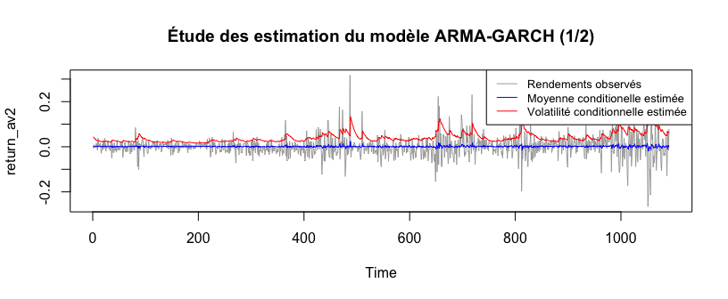

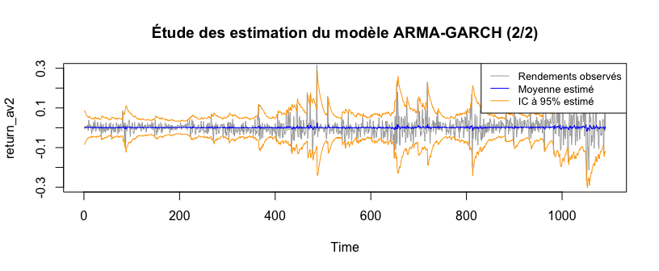

Sur le premier graphique on observe que la moyenne estimée (en bleu) semble bien s’ajuster aux données observées. Dans des périodes ou les rendements observés sont très positifs (resp. négatifs) notre modèle estime une moyenne conditionnelle élevée (resp. faible), cela s’observe notamment autour de l’observation 480 (resp. 800). L’estimation de la variance conditionnelle semble aussi bien s’ajuster aux données, dans des périodes où les rendements s’éloignent fortement de la moyenne (positivement ou négativement) on observe une augmentation de la volatilité conditionnelle estimée. À l’inverse quand les observations sont proches de la moyenne la volatilité estimée est plutôt faible.

### 3.2.5 Conclusion de la modélisation

L’ensemble des tests et observations réalisés sur la modélisation des rendements nous indiquent que le modèle s’ajuste de manière satisfaisante aux données, capturant à la fois les variations de la moyenne conditionnelle et les dynamiques de volatilité. On continue notre étude en utilisant ce modèle pour faire des prévisions sur l’évolution de la moyenne et de la volatilité des rendements.

# 4 Prévision

Pour observer comment la série du ttf se serait comportée sans choc en février 2022 due à la guerre en Ukraine, nous allons utiliser la modélisation précédente pour faire des prévisions.

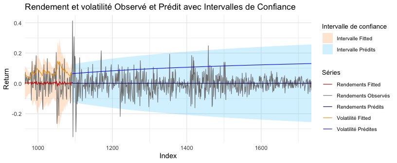

Ce graphique présente les observations, le modèle ajusté et les prévisions réalisées. Sur le long terme, pour la moyenne conditionnelle, les erreurs passées et les effets de l’autocorrélation perdent leur influence. La moyenne prédite tend vers une moyenne constante. La prévision de la volatilité sur le long terme est légèrement croissante ainsi l’intervalle de confiance prédit s’élargit légèrement avec le temps. On observe que certaines observations ne sont pas dans l’intervalle de confiance prédit, notre prévision ne capture pas les périodes de volatilité exceptionnellement élevée. Aussi, graphiquement, la volatilité des observations semble diminuer entre les périodes 1090 et 1700. Après la période 1500 il n’y a plus de rendements extrêmes et l’amplitude des rendements observés diminue, notre prédiction est en contradiction avec ces observations car notre prévision donne un volatilité croissante sur cette même période. Notre prévision est donc de moins en moins précise à mesure que l’on s’éloigne des données observées.

La réalisation de prévisions sur le long terme avec notre modèle présente des limites. Nous faisons donc le choix de ne pas modéliser le choc sur les rendements du 22 février, mais nous utilisons notre modèle et ses paramètres estimés pour étudier le comportement de la volatilité conditionnelle face à un choc. Dans la suite de notre étude nous nous concentrerons sur la volatilité conditionnelle.

# 5 VIRF

Une Volatility Impulse Response Function (VIRF) permet d’évaluer l’effet d’un choc éxogène sur la volatilité conditionnelle. C’est une extension de l’Impulse Response Function (IRF) qui est associée aux modèles VAR. Cette extension à été introduite par les travaux de Lin (1997) qui formalise l’Impulse Response Function dans un modèle GARCH pour la volatilité conditionnelle des taux de change.

Lin définit la fonction VIRF dans un modèle multivarié, si on l’adapte à un modèle univarié qu’est le nôtre, la VIRF s’écrit comme suit :

$$R_s = E(\sigma_{t+s}^2|\varepsilon_t = \varepsilon_0 + \delta) -
E(\sigma_{t+s}^2|\varepsilon_t = \varepsilon_0)$$

Avec :

- $R_s$ : La réponse impulsionnelle au choc sur la volatilité future pour un horizon s.
- $\sigma_{t+s}^2$ : La variance conditionnelle prédite à l’horizon t+s
- $\varepsilon_t$ : L’innovation à l’instant t.
- $\varepsilon_0$ : La valeur initiale de l’innovation avant qu’un choc ne se produise.
- $\delta$ : Le choc exogène.

Le premier terme ($E(\sigma_{t+s}^2|\varepsilon_t = \varepsilon_0 + \delta)$) correspond à la variance conditionnelle attendue après un choc $\delta$. Tandis que le second terme ($E(\sigma_{t+s}^2|\varepsilon_t = \varepsilon_0)$) correspond à la variance conditionnelle attendue en absence de choc.

Cette fonction peut être utilisée pour deux cas distincts. Le premier, pour modéliser comment réagit la variance conditionnelle face à un choc exogène hypothétique de niveau $\delta$. Le second consiste à observer comment un choc réel de niveau $\delta$ se dissipe. Dans les deux cas on observe comment, selon la structure de la volatilité conditionnelle, le choc se dissipe. Dans la suite de notre étude nous allons nous concentrer sur le premier cas.

On va réaliser la VIRF avec le modèle ARMA-GARCH estimé pour l’évolution des rendements avant invasion de l’Ukraine puis nous modéliserons l’évolution des rendements après invasion de l’Ukraine pour réaliser la VIRF de la période post-invasion. En comparant les deux VIRF on sera en mesure de savoir si l’invasion de l’Ukraine à impacté la structure de la variance conditionnelle des rendements du TTF. C’est à dire si un choc exogène impactait différemment la variance avant invasion de l’Ukraine par rapport à maintenant.

## 5.1 VIRF 1, avant invasion

Pour étudier comment, avant l’invasion de l’Ukraine, la volatilité conditionnelle réagit face à un choc exogène on reprend les estimateurs du modèle GARCH de cette période. Par souci de simplification on décide de fixer la valeur initiale de l’innovation à 0 ($\varepsilon_0=0$) et on définit le choc exogène de façon unitaire ($\delta=1$). La VIRF permet de mesurer l’écart dans l’évolution de la volatilité conditionnelle après ce choc unitaire, en comparant la dynamique avec et sans. Pour initialiser l’évolution de la variance conditionnelle on prend la dernière valeur ajusté par le modèle.

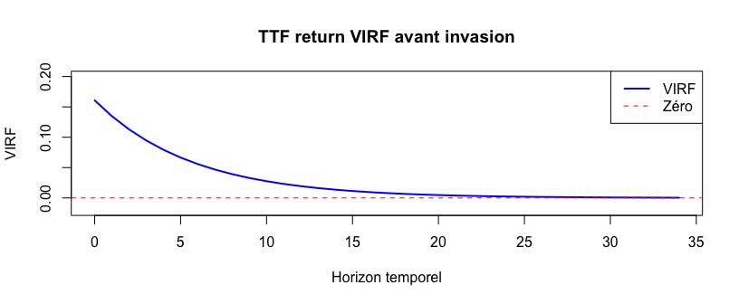

Au moment du choc, en t = 0, on observe une différence de 0.16. La volatilité augmente donc de 0.16 en réponse à un choc exogène unitaire, toutes choses égales par ailleurs. Ensuite la réponse au choc (ligne bleue) diminue progressivement avec l’horizon temporel post-choc. La réponse décroît de façon exponentielle et dès 6 jours après le choc l’effet n’est plus que de 0.05. La VIRF semble retrouver un niveau égal à 0 après 26 jours ce qui indique que l’effet du choc se dissipe totalement en 26 jours.

Pour pouvoir étudier si la réponse de la volatilité est similaire ou non dans la période après-invasion il est nécessaire de modéliser cette période.

## 5.2 VIRF 2, après invasion et comparaison

La modélisation de la série des rendements après invasion a été réalisée en suivant la même méthode que pour la période avant invasion. Cette partie est détaillée en annexe.

C’est suite à cette modélisation d’un deuxième modèle GARCH que l’on peut faire la VIRF pour cette seconde période.

On choisit la même valeur initiale de l’innovation et on reconsidère le choc unitaire. Ici on vient fixer la volatilité initiale avec la première volatilité ajusté par le modèle.

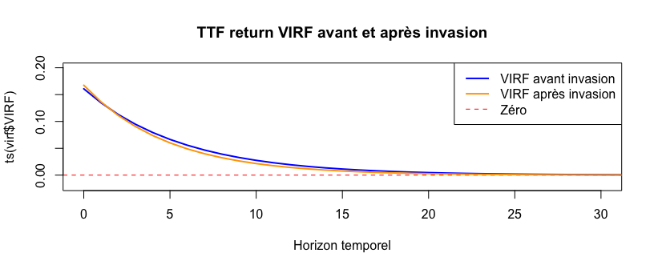

En orange on observe la VIRF pour cette seconde période et en la comparant avec celle de la première période, il ne semble pas y avoir de différence significative. La VIRF après invasion est légèrement plus élevée en t=0 et semble décroître à peine plus rapidement que la VIRF avant invasion. Il est important de noter que la différence dans la réponse au choc en 0 peut s’expliquer par le choix de la volatilité initiale. Il serait plus prudent de réaliser des tests statistiques sur ces deux VIRF pour prouver l’absence ou non de différence dans le comportement de la volatilité conditionnelle avant et après invasion.

# 6 Conclusion

Notre travail aborde spécifiquement la structure de la volatilité des rendements sur le marché du TTF et comment l’invasion de l’Ukraine impacte celle-ci. On a modélisé la moyenne et la volatilité des rendements avec un modèle ARMA-GARCH. Nous avons observé la dynamique de la volatilité avant et après l’invasion de l’Ukraine. Nos résultats montrent que bien que des différences de volatilité aient été constatées entre les périodes avant et après l’invasion, la structure de la volatilité conditionnelle semble n’avoir subi que peu de changements significatifs sur le temps long. En effet, la comparaison des VIRF des deux périodes révèle des variations modérées de la volatilité conditionnelle face à un choc exogène, suggérant que l’invasion de l’Ukraine n’a pas eu d’impact drastique sur la dynamique de la volatilité des rendements du TTF.

En conclusion, bien que notre modèle ARMA-GARCH fournisse une analyse pertinente de la volatilité des rendements, il reste des pistes pour approfondir notre compréhension de l’impact de l’invasion de l’Ukraine sur le marché des contrats à terme en gaz naturel, notamment en élargissant l’étude à des modèles plus complexes et à des analyses multivariées.

# 7 Annexe

## 7.1 A-Modélisation de la série après la guerre

Nous présentons dans cette partie la modélisation de la série après la guerre. Nous avons développé les principes de la modélisation et justifié les étapes dans la modélisation de la série du ttf de l’avant guerre. Ici nous allons reproduire l’analyse, en moins développé, pour la série d’après guerre :

### 7.1.1 Stationnarité de la série des rendements

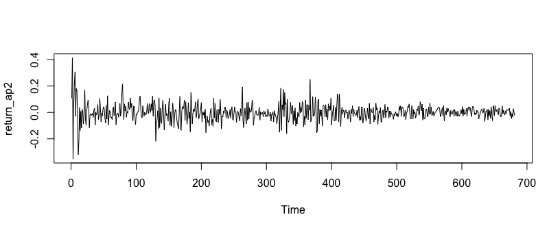

La série paraît stationnaire malgré quelques pics de volatilité plus importants. On la teste statistiquement :

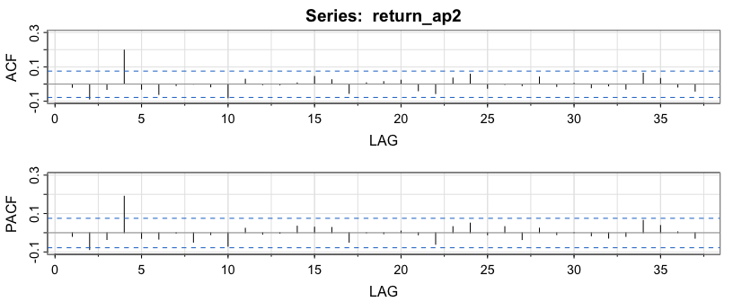

Les ACF / PACF montrent que la série semble avoir des caractéristiques de série stationnaire. On voit qu’un pic légèrement significatif au lag 4 ce qui pourrait venir des erreurs potentielles de test à 5%.

```
## Augmented Dickey-Fuller Test
## alternative: stationary
##
## Type 1: no drift no trend
##      lag   ADF p.value
## [1,]   0 -26.6    0.01
## [2,]   1 -21.3    0.01
## [3,]   2 -16.4    0.01
## [4,]   3 -11.3    0.01
## [5,]   4 -11.1    0.01
## [6,]   5 -11.1    0.01
## [7,]   6 -10.4    0.01
## Type 2: with drift no trend
##      lag   ADF p.value
## [1,]   0 -26.6    0.01
## [2,]   1 -21.3    0.01
## [3,]   2 -16.4    0.01
## [4,]   3 -11.3    0.01
## [5,]   4 -11.1    0.01
## [6,]   5 -11.2    0.01
## [7,]   6 -10.4    0.01
## Type 3: with drift and trend
##      lag   ADF p.value
## [1,]   0 -26.6    0.01
## [2,]   1 -21.3    0.01
## [3,]   2 -16.3    0.01
## [4,]   3 -11.3    0.01
## [5,]   4 -11.1    0.01
## [6,]   5 -11.2    0.01
## [7,]   6 -10.5    0.01
## ----
## Note: in fact, p.value = 0.01 means p.value <= 0.01
```

```
## $type1
##      lag       ADF p.value
## [1,]   0 -26.60848    0.01
## [2,]   1 -21.28419    0.01
## [3,]   2 -16.35350    0.01
## [4,]   3 -11.32124    0.01
## [5,]   4 -11.08851    0.01
## [6,]   5 -11.13156    0.01
## [7,]   6 -10.38998    0.01
##
## $type2
##      lag       ADF p.value
## [1,]   0 -26.59821    0.01
## [2,]   1 -21.29271    0.01
## [3,]   2 -16.35663    0.01
## [4,]   3 -11.32949    0.01
## [5,]   4 -11.10657    0.01
## [6,]   5 -11.16396    0.01
## [7,]   6 -10.43004    0.01
##
## $type3
##      lag       ADF p.value
## [1,]   0 -26.57945    0.01
## [2,]   1 -21.28701    0.01
## [3,]   2 -16.34694    0.01
## [4,]   3 -11.32648    0.01
## [5,]   4 -11.11152    0.01
## [6,]   5 -11.18369    0.01
## [7,]   6 -10.45981    0.01
```

```
## KPSS Unit Root Test
## alternative: nonstationary
##
## Type 1: no drift no trend
##  lag  stat p.value
##    6 0.268     0.1
## -----
##  Type 2: with drift no trend
##  lag  stat p.value
##    6 0.103     0.1
## -----
##  Type 1: with drift and trend
##  lag   stat p.value
##    6 0.0955     0.1
## -----------
## Note: p.value = 0.01 means p.value <= 0.01
##     : p.value = 0.10 means p.value >= 0.10
```

Les tests de Dickey Fuller et du KPSS donnent les mêmes conclusions : La série est stationnaire avec ou sans drift.

Test de Tiao-Tsay :

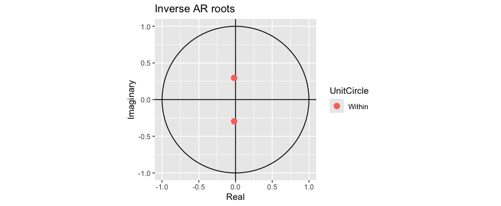

Le test de Tiao-Tsay confirme cela. La série est I(0), il n’y a pas de racine unitaire.

Finalement, la série après la guerre est stationnaire.

### 7.1.2 Modélisation de la moyenne conditionnelle

On commence par réaliser les EACF

```
## AR/MA
##   0 1 2 3 4 5 6 7 8 9 10 11 12 13
## 0 o x o x o o o o o x o  o  o  o
## 1 x o o x x o o o o o o  o  o  o
## 2 x x o x x o o o o o o  o  o  o
## 3 x x x o x o o o o o o  o  o  o
## 4 x x x x x o o o o o o  o  o  o
## 5 x x x x x o o o o o o  o  o  o
## 6 x x x x o x o o o o o  o  o  o
## 7 o x x o o x x o o o o  o  o  o
```

L’EACF montre qu’un ARMA(0,4) pourrait convenir.

Résultats des estimations du modèle ARIMA

|  | Parameter | Estimate | Std..Error | t.value | P.Value |
| --- | --- | --- | --- | --- | --- |
| **ma1** | ma1 | -0.0002853 | 0.03727 | -0.007656 | 0.9939 |
| **ma2** | ma2 | -0.06358 | 0.03791 | -1.677 | 0.0935 |
| **ma3** | ma3 | -0.03746 | 0.03974 | -0.9426 | 0.3459 |
| **ma4** | ma4 | 0.2225 | 0.03893 | 5.714 | 1.105e-08 |
| **intercept** | intercept | -0.001039 | 0.002659 | -0.3909 | 0.6959 |

#### 7.1.2.1 Analyse des résidus :

Test de Ljung-Box :

```
##
##  Box-Ljung test
##
## data:  residuals(arma04)
## X-squared = 6.7054, df = 10, p-value = 0.7529
```

Les résultats du test de Box-Ljung montrent une p-value de 0.7529, ce qui est bien supérieur au seuil de 5 %. Cela indique que nous ne pouvons pas rejeter l’hypothèse nulle selon laquelle les résidus du modèle ARMA(0,4) sont indépendants et ne présentent pas d’autocorrélation significative. Par conséquent, les résidus sont indépendants et ne présentent pas d’autocorrélation.

ACF/PACF :

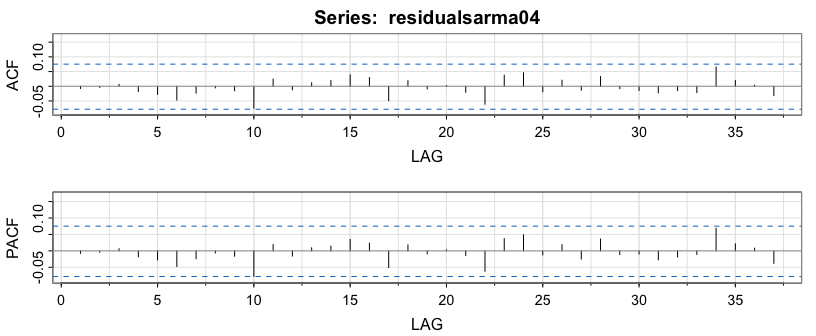

Les ACF/PACF des résidus confirment cela. Il n’y a pas d’autocorrélations dans les résidus. Donc la moyenne conditionnelle semble bien modélisée par l’ARMA. On s’intéresse maintenant à la variance conditionnelle.

Détection de l’hétéroscédasticité

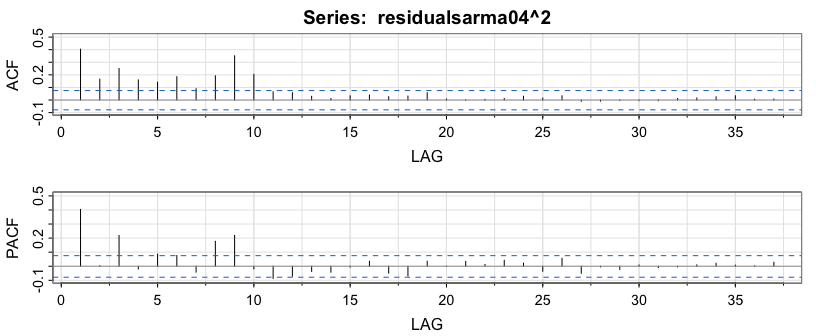

Plusieurs lags (en particulier les premiers) présentent des autocorrélations significatives. Cela suggère une **dépendance temporelle dans les variances** des résidus, ce qui est un signe clair d’hétéroscédasticité conditionnelle.

On confirme cette observation avec un test de Ljung-Box sur les résidus au carré.

```
##
##  Box-Ljung test
##
## data:  residualsarma04^2
## X-squared = 259.56, df = 8, p-value < 2.2e-16
```

La p-valeur strictement inférieure à 5% montre bien que les résidus au carré présentent de l’autocorrélation. Les résidus présentent une **hétéroscédasticité**. Cela suggère que la variance des résidus n’est pas constante dans le temps.

Test ARCH :

```
##
##  ARCH LM-test; Null hypothesis: no ARCH effects
##
## data:  residualsarma04
## Chi-squared = 113.94, df = 3, p-value < 2.2e-16
```

La faible p-valeur du test ARCH signifie que la variance conditionnelle des résidus dépend des valeurs passées. Autrement dit, les résidus ne sont pas homoscédastiques, mais leur variance évolue dans le temps. Le modèle ARMA ne capture pas toutes les caractéristiques des rendements, en particulier il ignore la dynamique de la volatilité.

Pour capturer cette dynamique de volatilité conditionnelle on va utiliser un modèle GARCH.

### 7.1.3 Modélisation de la partie GARCH

Comme dit précédemment, il faut s’intéresser à la distribution des observations.

Distribution de la série :

```
##
##  Jarque-Bera Normality Test
##
## data:  as.numeric(return_ap2)
## JB = 1022.8, p-value < 2.2e-16
## alternative hypothesis: greater
```

```
## Excess Kurtosis = 2.967109
```

```
## Skewness = 0.3310389
```

La p-valeur du test de Jarque-Bera est extrêmement faible (<5%), ce qui conduit au rejet de l’hypothèse nulle. Cela signifie que la distribution des rendements ne suit pas une loi normale. Ce constat est renforcé par l’excès de kurtosis, nettement supérieur à 0, et une skewness positive. L’excès de kurtosis indique que la distribution possède des queues épaisses, ce qui suggère une fréquence plus élevée de valeurs extrêmes par rapport à une loi normale. La skewness de 0.33 révèle une asymétrie à droite, avec une queue plus longue du côté des rendements positifs. Ainsi, les rendements positifs extrêmes sont plus fréquents que les rendements négatifs extrêmes.

[figure not shown]

Le diagramme Quantile-Quantile montre qu’au centre de la distribution les rendements ressemblent à une loi normale mais au niveau de la q**ueue de gauche** les points dévient fortement sous la ligne rouge et au niveau de la **Queue de droite l**es points dévient également au-dessus de la ligne rouge.

Ainsi la distribution des rendements **n’est pas normale**.

Ces observations correspondent plutot à une distribution de Skew-t qui capture mieux l’asymètrie et les queues épaisses. Comme il y a présence d’hétéroscédasticité, nous modélisons le GARCH avec cette distribution puis nous vérifierons, dans les diagnostics que les résidus du modèle suivent aussi une Skew-t.

#### 7.1.3.1 Identification de la partie GARCH(p,q)

Nous avons précédemment détecter de l’hétéroscédasticité. On va tester différentes structures de GARCH et d’ARMA. D’après les eacf des rendements au carré présentés ci-dessous, on commence cette modélisation avec un ordre 1,3 pour la partie GARCH du modèles Pour la partie de la moyenne conditionnelle, on va se baser sur le modèle ARMA précédente (p=0, q=4)

```
## AR/MA
##   0 1 2 3 4 5 6 7 8 9 10 11 12 13
## 0 x x x x x x x x x x o  o  o  o
## 1 x x x o o x x o x o o  o  o  o
## 2 x x x o o x x o o o o  o  o  o
## 3 x x x o o o o o o o o  o  o  o
## 4 x o x x o o o o o o o  o  o  o
## 5 x x x x x o o o o o o  o  o  o
## 6 x x x o x x o o o o o  o  o  o
## 7 x x x o x x x o o o o  o  o  o
```

| Parameter | Estimate | P.Value |
| --- | --- | --- |
| mu | -0.0014896 | 0.3756106 |
| ma1 | -0.0674866 | 0.1061288 |
| ma2 | -0.0626783 | 0.1027233 |
| ma3 | -0.0342490 | 0.3674777 |
| ma4 | 0.1254623 | 0.0017765 |
| omega | 0.0001101 | 0.0338458 |
| alpha1 | 0.1987027 | 0.0000049 |
| beta1 | 0.6328755 | 0.0000000 |
| beta2 | 0.0000004 | 0.9999995 |
| beta3 | 0.1485947 | 0.7311127 |
| skew | 1.1161505 | 0.0000000 |
| shape | 7.3061842 | 0.0000066 |

Coefficients des estimateurs du modèle ARMA(0,0)-GARCH(1,1)

| Parameter | Estimate | P.Value |
| --- | --- | --- |
| mu | -0.0015800 | 0.3508759 |
| omega | 0.0000853 | 0.0343617 |
| alpha1 | 0.1674500 | 0.0000084 |
| beta1 | 0.8146561 | 0.0000000 |
| skew | 1.0809117 | 0.0000000 |
| shape | 9.6372497 | 0.0005832 |

##### 7.1.3.1.1 Diagnostics

Pour évaluer la qualité de l’ajustement du modèle GARCH(1,1), plusieurs tests de diagnostic portant sur les résidus standardisés et les résidus au carré sont réalisés. Les résultats de ces tests sont présentés par la commande ugarchfit() à la suite des estimations. Ces tests permettent de vérifier si les hypothèses du modèle sont satisfaites, en particulier l’absence de corrélation et la capture des effets d’hétéroscédasticité.

```
##
## *---------------------------------*
## *          GARCH Model Fit        *
## *---------------------------------*
##
## Conditional Variance Dynamics
## -----------------------------------
## GARCH Model  : sGARCH(1,1)
## Mean Model   : ARFIMA(0,0,0)
## Distribution : sstd
##
## Optimal Parameters
## ------------------------------------
##         Estimate  Std. Error  t value Pr(>|t|)
## mu     -0.001580    0.001694 -0.93289 0.350876
## omega   0.000085    0.000040  2.11580 0.034362
## alpha1  0.167450    0.037597  4.45379 0.000008
## beta1   0.814656    0.036315 22.43307 0.000000
## skew    1.080912    0.064224 16.83035 0.000000
## shape   9.637250    2.802101  3.43929 0.000583
##
## Robust Standard Errors:
##         Estimate  Std. Error  t value Pr(>|t|)
## mu     -0.001580    0.001803 -0.87625 0.380893
## omega   0.000085    0.000038  2.24073 0.025044
## alpha1  0.167450    0.037687  4.44314 0.000009
## beta1   0.814656    0.036451 22.34907 0.000000
## skew    1.080912    0.057110 18.92690 0.000000
## shape   9.637250    2.971024  3.24375 0.001180
##
## LogLikelihood : 1042.154
##
## Information Criteria
## ------------------------------------
##
## Akaike       -3.0430
## Bayes        -3.0032
## Shibata      -3.0432
## Hannan-Quinn -3.0276
##
```

[output cut: 43 more lines]

```
## Negative Sign Bias  0.6175 0.537089
## Positive Sign Bias  1.0119 0.311964
## Joint Effect       13.6680 0.003394 ***
##
##
## Adjusted Pearson Goodness-of-Fit Test:
## ------------------------------------
##   group statistic p-value(g-1)
## 1    20     11.36       0.9110
## 2    30     23.10       0.7721
## 3    40     22.26       0.9856
## 4    50     40.95       0.7863
##
##
## Elapsed time : 0.07908702
```

**Ljung-Box**

Le test de Ljung-Box pondéré examine la présence d’autocorrélation dans les résidus standardisés du modèle. Dans le cas de notre modèle, les p-valeurs pour les différents lags sont élevées (p = 0.7792 pour le lag 1, p = 0.6292 pour le lag 2, et p = 0.1237 pour le lag 5), ce qui signifie que nous ne pouvons pas rejeter l’hypothèse nulle. Cela indique que les résidus standardisés ne présentent pas d’autocorrélation significative, ce qui suggère que le modèle capture bien les dépendances dynamiques dans la série temporelle.

**Ljung-Box Test sur les résidus au carré**

Ce même test appliqué aux résidus au carré permet de vérifier l’absence de corrélation dans la variance conditionnelle. Ici, l’objectif est de tester si les effets d’hétéroscédasticité ont été correctement modélisés. Sous H_0, il n’y a pas de corrélation significative entre les résidus au carré. Les p-valeurs obtenues (p = 0.1658 pour le lag 1, p = 0.5716 pour le lag 5, et p = 0.7398 pour le lag 9) montrent que nous ne rejetons pas l’hypothèse nulle. Par conséquent, les résidus au carré ne présentent pas de dépendances significatives, ce qui indique que le modèle GARCH capture efficacement l’hétéroscédasticité de la série.

**ARCH LM Tests**

Le test ARCH LM vérifie spécifiquement la présence d’effets ARCH résiduels non capturés par le modèle. Ce test repose sur l’hypothèse nulle selon laquelle il n’y a pas de dépendance conditionnelle dans la variance (c’est-à-dire que le modèle a correctement modélisé les effets ARCH). Les p-valeurs pour les différents lags (p = 0.7351 pour le lag 3, p = 0.9246 pour le lag 5, et p = 0.9417 pour le lag 7) indiquent que nous ne rejetons pas l’hypothèse nulle. Donc le modèle a correctement spécifié la structure de la variance conditionnelle, et il n’existe pas d’effet ARCH résiduel significatif.

**Adjusted Pearson Goodness-of-Fit Test**

L’objectif est de vérifier si les résidus standardisés du modèle sont compatibles avec la densité théorique spécifiée, ici la distribution sstd. Une statistique chi-deux est calculée à partir des écarts entre les fréquences observées et les fréquences attendues dans des groupes (g), et une p-valeur est associée pour tester l’hypothèse nulle selon laquelle les résidus suivent la distribution théorique. Pour g = 20, la statistique est de 11.36, avec une p-valeur de 0.9110. Une p-valeur aussi élevée permet de ne pas rejetter l’hypothèse nulle. Pour les groupes de 30 à 50 les p-valeurs sont aussi élevée donc on ne rejette pas l’hypothèse nulle pour tout les groupe. Ainsi les résidus standardisé du modèle sont compatibles avec la distribution théorique choisie (sstd), confirmant la pertinence de cette spécification pour modéliser les données.

**Conclusion**

Ces résultats montrent que le modèle GARCH(1,1) ajusté sur les données satisfait aux hypothèses de base. Les tests de Ljung-Box sur les résidus standardisés et les résidus au carré confirment l’absence de corrélation linéaire et de dépendances dans la variance conditionnelle, respectivement. De plus, le test ARCH LM ne révèle aucun effet ARCH résiduel significatif. Enfin le test d’ajustement de Pearson montre que le modèle produit des résidus qui suivent la distribution théorique. Ainsi, le modèle semble bien adapté pour représenter la dynamique de la moyenne et de la variance conditionnelles de la série étudiée.

Comme pour le modèle précédent, nous pouvons réaliser une comparaison avec les observations, pour vérifier la consistance du modèle.

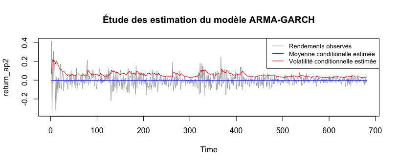

Sur ce graphique on observe que la moyenne estimée (en bleu) semble bien s’ajuster aux données observées avec une moyenne égale à 0. L’estimation de la variance conditionnelle semble bien s’ajuster aux données, dans des périodes où les rendements s’éloignent fortement de la moyenne (positivement ou négativement) on observe une augmentation de la volatilité conditionnelle estimée. À l’inverse quand les observations sont proches de la moyenne la volatilité estimée est plutôt faible.

# 8 Bibliographie

Bali, R., Guirguis, H. (2007), “Extreme observations and non-normality in ARCH and GARCH”, *International Review of Economics & Finance*, 16 (3), 332-346, https://doi.org/10.1016/j.iref.2005.05.003

Bollerslev, T. (1986), “Generalized autoregressive conditional heteroskedasticity”, *Journal of Econometrics*, 31 (3), 307-327, https://doi.org/10.1016/0304-4076(86)90063-1

Cryer, J. D., Chan, K.-S. (2008), *Time Series Analysis: With Applications in R*, 2e édition, Springer Science+Business Media, ISBN 978-0-387-75958-6.

Engle, R. F. (1982), “Autoregressive Conditional Heteroscedasticity with Estimates of the Variance of United Kingdom Inflation”, *Econometrica*, 50(4), 987–1007, https://doi.org/10.2307/1912773

Galanos, A. (2024), *rugarch: Univariate GARCH models*. R package version 1.5-3.

Hafner, C. M., Herwartz, H. (2006), “Volatility impulse responses for multivariate GARCH models: An exchange rate illustration”, *Journal of International Money and Finance*, 25 (5), 719-740, https://doi.org/10.1016/j.jimonfin.2006.04.006

Lambert, P., Laurent, S. (2002), “Modelling skewness dynamics in series of financial data using skewed location-scale distributions”.

Lin, W.-L. (1997), “Impulse Response Function for Conditional Volatility in GARCH Models”, *Journal of Business & Economic Statistics*, 15(1), 15–25, https://doi.org/10.2307/1392069

Liu, H., Shi, J. (2013), “Applying ARMA–GARCH approaches to forecasting short-term electricity prices”, *Energy Economics*, 37, 152-166, https://doi.org/10.1016/j.eneco.2013.02.006

Qi, H., Wang, Y. (2022), “Prediction and Analysis of Stock Logarithmic Returns Based on ARMA-GARCH Model”, *Proceedings of CECNet 2022*, A.J. Tallón-Ballesteros (Ed.), IOS Press, https://doi.org/10.3233/FAIA220575

Tsuji, C. (2024), “Simmering tensions on the Russia–Ukraine border and natural gas futures prices: identifying the impact using new hybrid GARCH”, *Energy Informatics*, 7, 37, https://doi.org/10.1186/s42162-024-00336-0

Zheng, Y., Luo, J., Chen, J., Chen, Z., and Shang, P. (2023), “Natural gas spot price prediction research under the background of Russia-Ukraine conflict—based on FS-GA-SVR hybrid model,” *Journal of Environmental Management*, 344, 118446, https://doi.org/10.1016/j.jenvman.2023.118446